# 04 Filling in a simple IPM

# Defining the range of integration

Having defined the numerical integration rules and model iteration procedure, we now need to define the bounds for the integration. The bounds correspond to the $L,U$ below and above the integral in Eq 1. The `define_domains()` function takes at least two, but possibly more arguments:

1. `proto_ipm`: the object created by `init_ipm()`/`define_kernel()`/`define_impl()`
2. `...`: these are named expressions. The names are the name of the trait. The values should be a vector with 3 entries, `c(L, U, m)`, where:
   - `L` is the smallest value the trait can have,
   - `U` is the largest value the trait can have,
   - `m` is the number of mesh points to divide the interval into.

It is fairly common practice to extract the smallest and largest values from the raw data, and then pad them by 15-20% to account for the possibility that we did not sample the smallest/largest individuals in the population. This chunk extracts those values from the `carp_df` object.

```r
L <- min(c(carp_df$log_size, carp_df$log_size_next), na.rm = TRUE) * 1.2
U <- max(c(carp_df$log_size, carp_df$log_size_next), na.rm = TRUE) * 1.2
m <- 100
```

**Note**: We multiply the `L` value by 1.2 because it is negative, and we want to make it more negative (*i.e.* smaller). If it were a positive value, we would multiply it by 0.8.

## Exercise 8:

**Try defining the domain for the integration for `carpobrotus_ipm` object in the code below, using the limits calculated above**

```r
carpobrotus_ipm <- define_domains(
  proto_ipm = ___,
  ___ = c(___, ___, ___)
)
```

**Hint**

```r
carpobrotus_ipm <- define_domains(
  proto_ipm = carpobrotus_ipm,
  z = c(___, ___, ___)
)
```

# Defining the initial trait distribution

The initial trait distribution is usually the last piece of information required to define a model with `ipmr`. This defines $n(z,t=1)$ from Eq 1. This function has 3 arguments, though only two are used at a time:

1. `proto_ipm`: the object created by `init_ipm()`/`define_kernel()`/`define_impl()`/`define_domains()`. It is always used!
2. `...`: These are named expressions. The name corresponds to the trait distribution with an `n_` prepended to it. For example, our IPM uses `z` to denote size, so we would name this `n_z`. The right hand side can be any *R* code that produces a numeric vector with the appropriate length (*i.e.* the number of mesh points `m` used to integrate over this particular state. For discrete states, this will always be a single number).
3. `pop_vectors`: Formatted as 2. This would be useful for using an observed population trait distribution as the starting point for a simulation (`ipmr` provides the function `discretize_pop_vector()` to help compute this from raw data).

In this example we will use a uniform vector as the initial trait distribution

```r
carpobrotus_ipm <- define_pop_state(
  proto_ipm = carpobrotus_ipm,
  n_z       = rep(1/m, m)
)
```

# Creating the IPM

`ipmr` has one function to convert `proto_ipm` objects into an IPM object - `make_ipm()`. This function takes the expressions we defined above and combines them to create a model iteration expression (Eq 1), then iterates the model the requested number of times to return sub-kernels, a time series of population trait distributions, and optionally, lists of environments that contain the vital rate function values. Below is a list of the arguments to `make_ipm()` for simple, density independent, deterministic models that we will use in this tutorial:

1. `proto_ipm`: the object created by `init_ipm()`/all `define_` functions.
2. `return_main_env`: this controls whether to return the so-called `main_env` object. This holds the integration mesh, weights, upper and lower bounds, and some other odds and ends that are useful for certain analyses. This defaults to `TRUE`.
3. `return_all_envs`: this controls whether to return all of the sub-kernel evaluation environments. These contain the vital rate function values, parameters, and a copy of the sub-kernels themselves. These are required for any downstream analyses that need vital rate function values. The default is `FALSE`, but we will set it to `TRUE` when we call `make_ipm()` in this tutorial.
4. `iterations`: this controls the number of iterations for the deterministic simulation. The default is 50, but we can bump that up if we have problems with convergence to asymptotic dynamics.

## Exercise 9:

**Use `make_ipm()` to create an IPM object for the `proto_ipm` using the initial trait distribution from above.**

```r
carpobrotus_ipm_unif <- make_ipm(
  proto_ipm       = carpobrotus_ipm,
  return_all_envs = ___,
  iterations      = ___
)
```

# Check for convergence

Next, we will run through some basic analyses that `ipmr` provides.

`ipmr` provides the `lambda` function to extract the asymptotic per-capita population growth rate ($\lambda$). Since all values are computed via iteration, we probably want to check and make sure our simulation converged to asymptotic dynamcis before proceeding. There are two functions to help with this:

```r
is_conv_to_asymptotic(carpobrotus_ipm_unif, tol = 1e-9)
```

```
## lambda
##  FALSE
```

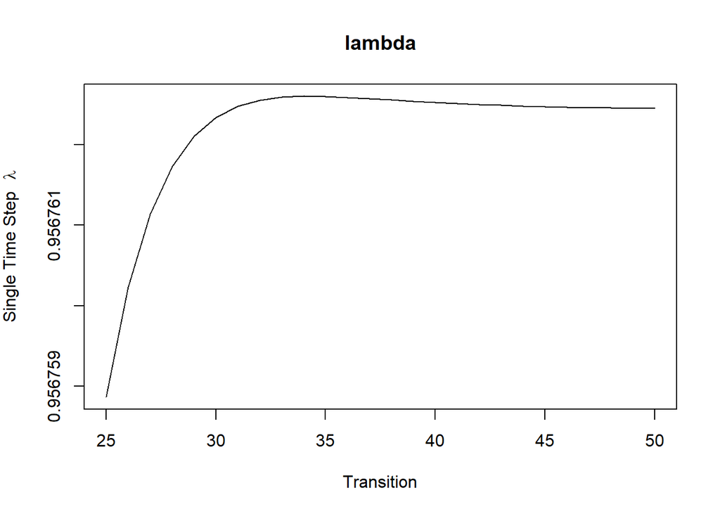

```r
conv_plot(carpobrotus_ipm_unif, iterations = 25:50)
```

We can see that the model has not converged to asymptotic dynamics at our requested tolerance, even though, the convergence plot looks pretty good.  
Since this is a simple model and runs pretty quickly, we will re-run it with 100 iterations and then try again.

## Exercise 10:

**Increase the number of iterations in `make_ipm()` to 100, and rerun the two functions above**

# Basic analysis

Now that we have an IPM, *and* we know it has converged to asymptotic dynamics, it’s time to get the per capita growth rate for *Carpobrotus*

## Exercise 11:

**Use the `lambda()` function to calculate the population growth rate for you IPM**

`ipmr` has a few more basic analysis functions for your IPM that you can find [here](https://levisc8.github.io/ipmr/reference/index.html#section-further-analyses).

# Wrap up

That’s it! you have created and analysed your very first IPM with `ipmr`. We have gone from vital rate models to define the IPM, running, checking and analysing it. `ipmr` is capable of a lot more complex IPMs, but with this tutorial and the extensive [vignettes](https://levisc8.github.io/ipmr/articles/ipmr-introduction.html) available, you should now be able to build whatever IPM your data needs!